# It Always Rains on Recycling Night

Overcoming negativity bias with data

Patrick Lyng Rutz

6/7/2019

### It’s a vivid memory…

It’s Tuesday - recycling night in the Heights, Jersey City. One by one, neighbors grab the usual bins for cardboard and bottles - dragging them to the curb.

“Wow it’s really coming down!”

That’s a shame, because by the time the sanitation workers come by they will have a soggy mess to contend with. Wait, this happened last week too… *deja vu*!

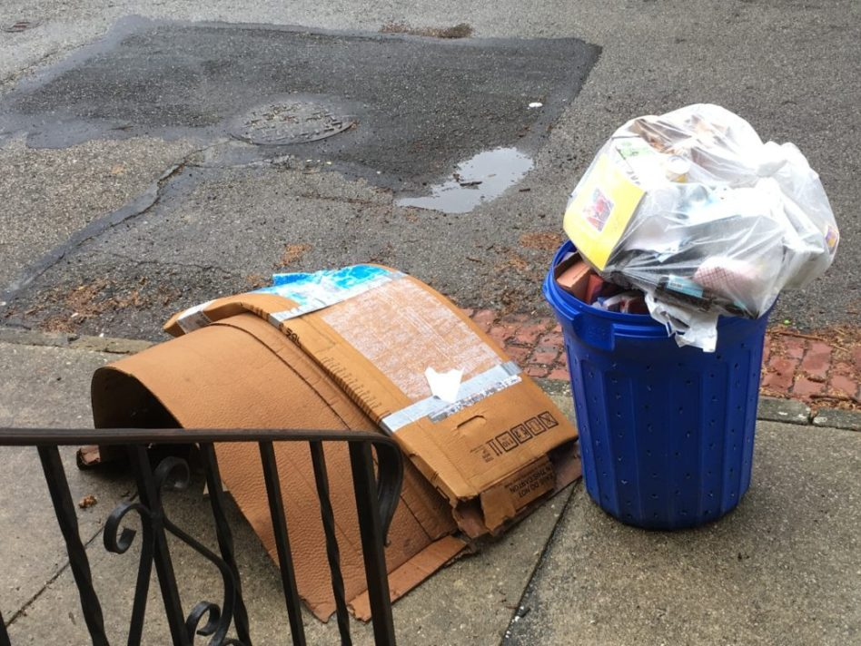

This familiar situation

**“It *always* rains on recycling night!”** …this became a sort of mantra between my friends and I some years back. It did seem uncanny, to the point where I was ready to believe that we had endured some sort of statistical anomaly in our years together.

### A textbook case of bias

All humans (and data) suffer from biases. This specific case is something called [Negativity Bias](https://www.psychologytoday.com/us/articles/200306/our-brains-negative-bias), which means the unpleasant memories of sloshy cardboard seemed to far outweigh/outnumber the mundane, dry nights.

As much as I’d love to, it’s impossible to turn this cognitive switch on and off. I *do* believe that a disproportionate number of recycling nights occurred on rainy days!

However, those of us in the analytics profession are equipped to answer things like this more definitively. Below, I intend to.

### NOAA public datasets

The [National Centers for Environment Information](https://www.ncdc.noaa.gov/) (part of the National Oceanic and Atmospheric Administration) provide the public with various datasets pertaining to climate in the US, gathered from a national network of weather stations.

I was able to use the [Find a Station](https://www.ncdc.noaa.gov/cdo-web/datatools/findstation) tool to access daily weather summaries for Newark International Airport, which is about 20 minutes away and should serve as an accurate location for historical precipitation figures.

*Weather station data example - available as .csv*

| STATION | NAME | DATE | PRCP | SNOW | SNWD | WT01 | WT02 | WT03 | WT04 | WT05 | WT06 | WT08 | WT09 | WT11 | WT13 | WT14 | WT15 | WT16 | WT17 | WT18 | WT22 |
| --- | --- | --- | --- | --- | --- | --- | --- | --- | --- | --- | --- | --- | --- | --- | --- | --- | --- | --- | --- | --- | --- |
| USW00014734 | NEWARK LIBERTY INTERNATIONAL AIRPORT, NJ US | 2012-01-12 | 1.35 | 0.0 | 0 | 1 | NA | NA | NA | NA | NA | NA | NA | NA | 1 | 1 | NA | 1 | NA | NA | NA |
| USW00014734 | NEWARK LIBERTY INTERNATIONAL AIRPORT, NJ US | 2012-01-13 | 0.10 | 0.0 | 0 | 1 | NA | NA | NA | NA | NA | NA | NA | NA | 1 | 1 | NA | 1 | NA | 1 | NA |
| USW00014734 | NEWARK LIBERTY INTERNATIONAL AIRPORT, NJ US | 2012-01-21 | 0.22 | 3.3 | 2 | NA | 1 | NA | 1 | NA | NA | NA | NA | NA | NA | 1 | NA | NA | NA | 1 | NA |
| USW00014734 | NEWARK LIBERTY INTERNATIONAL AIRPORT, NJ US | 2012-01-23 | 0.28 | 0.0 | 2 | 1 | NA | NA | NA | NA | NA | NA | NA | NA | 1 | 1 | NA | 1 | NA | 1 | NA |
| USW00014734 | NEWARK LIBERTY INTERNATIONAL AIRPORT, NJ US | 2012-01-27 | 0.35 | 0.0 | 0 | 1 | NA | NA | NA | NA | NA | NA | NA | NA | 1 | NA | NA | 1 | NA | NA | NA |
| USW00014734 | NEWARK LIBERTY INTERNATIONAL AIRPORT, NJ US | 2012-02-08 | 0.02 | 0.2 | 0 | 1 | NA | NA | NA | NA | NA | NA | NA | NA | 1 | NA | NA | NA | NA | 1 | NA |
| USW00014734 | NEWARK LIBERTY INTERNATIONAL AIRPORT, NJ US | 2012-02-09 | 0.00 | 0.0 | 0 | 1 | NA | NA | NA | NA | NA | NA | NA | NA | NA | NA | NA | NA | NA | 1 | NA |
| USW00014734 | NEWARK LIBERTY INTERNATIONAL AIRPORT, NJ US | 2012-02-11 | 0.08 | 0.1 | 0 | 1 | NA | NA | NA | NA | NA | NA | NA | NA | 1 | NA | NA | 1 | NA | 1 | NA |
| USW00014734 | NEWARK LIBERTY INTERNATIONAL AIRPORT, NJ US | 2012-02-29 | 0.44 | 0.0 | 0 | 1 | NA | NA | NA | NA | NA | NA | NA | NA | 1 | 1 | NA | 1 | NA | NA | NA |
| USW00014734 | NEWARK LIBERTY INTERNATIONAL AIRPORT, NJ US | 2012-03-01 | 0.06 | 0.0 | 0 | 1 | NA | NA | NA | NA | NA | NA | NA | NA | 1 | 1 | NA | 1 | NA | NA | NA |
| USW00014734 | NEWARK LIBERTY INTERNATIONAL AIRPORT, NJ US | 2012-03-02 | 0.25 | 0.0 | 0 | 1 | NA | NA | NA | NA | NA | NA | NA | NA | 1 | NA | NA | 1 | NA | NA | NA |
| USW00014734 | NEWARK LIBERTY INTERNATIONAL AIRPORT, NJ US | 2012-03-03 | 0.11 | 0.0 | 0 | 1 | NA | NA | NA | NA | NA | NA | NA | NA | 1 | 1 | NA | 1 | NA | NA | NA |
| USW00014734 | NEWARK LIBERTY INTERNATIONAL AIRPORT, NJ US | 2012-03-17 | 0.00 | 0.0 | 0 | 1 | 1 | NA | NA | NA | NA | 1 | NA | NA | 1 | NA | NA | NA | NA | NA | NA |
| USW00014734 | NEWARK LIBERTY INTERNATIONAL AIRPORT, NJ US | 2012-03-20 | 0.00 | 0.0 | 0 | 1 | 1 | NA | NA | NA | NA | 1 | NA | NA | 1 | NA | NA | NA | NA | NA | NA |
| USW00014734 | NEWARK LIBERTY INTERNATIONAL AIRPORT, NJ US | 2012-03-21 | 0.00 | 0.0 | 0 | 1 | 1 | NA | NA | NA | NA | 1 | NA | NA | NA | 1 | NA | NA | NA | NA | NA |
| USW00014734 | NEWARK LIBERTY INTERNATIONAL AIRPORT, NJ US | 2012-03-22 | 0.00 | 0.0 | 0 | NA | 1 | NA | NA | NA | NA | 1 | NA | NA | 1 | 1 | NA | NA | NA | NA | NA |
| USW00014734 | NEWARK LIBERTY INTERNATIONAL AIRPORT, NJ US | 2012-03-25 | 0.06 | 0.0 | 0 | 1 | NA | NA | NA | NA | NA | NA | NA | NA | NA | NA | NA | 1 | NA | NA | NA |
| USW00014734 | NEWARK LIBERTY INTERNATIONAL AIRPORT, NJ US | 2012-04-22 | 2.64 | 0.0 | 0 | 1 | NA | NA | NA | NA | NA | NA | NA | NA | 1 | NA | NA | 1 | NA | NA | NA |
| USW00014734 | NEWARK LIBERTY INTERNATIONAL AIRPORT, NJ US | 2012-04-23 | 0.14 | 0.0 | 0 | 1 | NA | NA | NA | NA | NA | NA | NA | NA | 1 | 1 | NA | 1 | NA | NA | NA |
| USW00014734 | NEWARK LIBERTY INTERNATIONAL AIRPORT, NJ US | 2012-04-26 | 0.02 | 0.0 | 0 | 1 | NA | NA | NA | NA | NA | NA | NA | NA | 1 | 1 | NA | 1 | NA | NA | NA |
| USW00014734 | NEWARK LIBERTY INTERNATIONAL AIRPORT, NJ US | 2012-04-27 | 0.00 | 0.0 | 0 | 1 | NA | NA | NA | NA | NA | NA | NA | NA | NA | NA | NA | 1 | NA | NA | NA |
| USW00014734 | NEWARK LIBERTY INTERNATIONAL AIRPORT, NJ US | 2012-05-06 | 0.00 | 0.0 | 0 | 1 | NA | NA | NA | NA | NA | NA | NA | NA | 1 | NA | NA | NA | NA | NA | NA |
| USW00014734 | NEWARK LIBERTY INTERNATIONAL AIRPORT, NJ US | 2012-05-09 | 0.22 | 0.0 | 0 | 1 | NA | NA | NA | NA | NA | NA | NA | NA | 1 | 1 | NA | 1 | NA | NA | NA |
| USW00014734 | NEWARK LIBERTY INTERNATIONAL AIRPORT, NJ US | 2012-05-22 | 0.15 | 0.0 | 0 | 1 | NA | NA | NA | NA | NA | NA | NA | NA | 1 | 1 | NA | 1 | NA | NA | NA |
| USW00014734 | NEWARK LIBERTY INTERNATIONAL AIRPORT, NJ US | 2012-05-24 | 0.20 | 0.0 | 0 | NA | 1 | 1 | NA | NA | NA | NA | NA | NA | NA | 1 | NA | NA | NA | NA | NA |
| USW00014734 | NEWARK LIBERTY INTERNATIONAL AIRPORT, NJ US | 2012-06-01 | 0.17 | 0.0 | 0 | 1 | NA | NA | NA | NA | NA | NA | NA | NA | 1 | NA | NA | 1 | NA | NA | NA |
| USW00014734 | NEWARK LIBERTY INTERNATIONAL AIRPORT, NJ US | 2012-06-04 | 0.56 | 0.0 | 0 | 1 | NA | NA | NA | NA | NA | NA | NA | NA | 1 | NA | NA | 1 | NA | NA | NA |
| USW00014734 | NEWARK LIBERTY INTERNATIONAL AIRPORT, NJ US | 2012-06-12 | 1.25 | 0.0 | 0 | 1 | NA | NA | NA | NA | NA | NA | NA | NA | 1 | NA | NA | 1 | NA | NA | NA |
| USW00014734 | NEWARK LIBERTY INTERNATIONAL AIRPORT, NJ US | 2012-06-13 | 0.28 | 0.0 | 0 | 1 | NA | NA | NA | NA | NA | NA | NA | NA | 1 | 1 | NA | 1 | NA | NA | NA |
| USW00014734 | NEWARK LIBERTY INTERNATIONAL AIRPORT, NJ US | 2012-06-20 | 0.00 | 0.0 | 0 | 1 | NA | NA | NA | NA | NA | NA | NA | NA | 1 | NA | NA | NA | NA | NA | NA |
| USW00014734 | NEWARK LIBERTY INTERNATIONAL AIRPORT, NJ US | 2012-07-20 | 0.63 | 0.0 | 0 | 1 | NA | NA | NA | NA | NA | NA | NA | NA | 1 | NA | NA | 1 | NA | NA | NA |
| USW00014734 | NEWARK LIBERTY INTERNATIONAL AIRPORT, NJ US | 2012-08-06 | 0.04 | 0.0 | 0 | 1 | NA | NA | NA | NA | NA | NA | NA | NA | 1 | 1 | NA | 1 | NA | NA | NA |
| USW00014734 | NEWARK LIBERTY INTERNATIONAL AIRPORT, NJ US | 2012-08-28 | 0.06 | 0.0 | 0 | 1 | NA | NA | NA | NA | NA | NA | NA | NA | 1 | NA | NA | 1 | NA | NA | NA |
| USW00014734 | NEWARK LIBERTY INTERNATIONAL AIRPORT, NJ US | 2012-09-03 | 0.08 | 0.0 | 0 | 1 | NA | NA | NA | NA | NA | NA | NA | NA | 1 | 1 | NA | 1 | NA | NA | NA |
| USW00014734 | NEWARK LIBERTY INTERNATIONAL AIRPORT, NJ US | 2012-09-04 | 0.94 | 0.0 | 0 | 1 | NA | NA | NA | NA | NA | NA | NA | NA | 1 | NA | NA | 1 | NA | NA | NA |

The NCEI also provides the corresponding [data definitions](https://www.ncdc.noaa.gov/cdo-web/datasets) for the weather type “WT”. Here is the direct [link](https://www1.ncdc.noaa.gov/pub/data/cdo/documentation/GHCND_documentation.pdf).

WT16 is described as *“Rain (may include freezing rain, drizzle, and freezing drizzle)”* which sounds like an appropriate description of what we’re after.

### The chi-squared test

Let’s turn this vague superstition into something testable.

> H<sub>1</sub>: It rains disproportionately on different weekdays.  
> H<sub>0</sub>: It rains equally across every weekday.

There is a straightforward approach for this called the [chi-squared Goodness of Fit test](https://stattrek.com/chi-square-test/goodness-of-fit.aspx), otherwise known as the test of homogeneity. This is different than than more common test of independence (also referred to as chi squared). Either test requires discrete distributions of categorical variables. This is what WT16 represents, a binary classification of rainy weather which we can count in a contingency table.

We will test the probability that the true population of rainy days is equal across all weekdays. Put plainly, we assume that proportionately each weekday will have 14.3% of the total rainy days.

### Data preparation

This section will explain a few transformations with example code.  
**Click here to skip past the data prep**.

The available data is relatively clean, so it is easily imported without specifying types by the readr package. As a bonus, the DATE field politely defaults to date type.

```r
nw <- readr::read_csv("noaa_newark_data.csv")

# The Date is correct
str(nw$DATE)
```

```
##  Date[1:2711], format: "2012-01-01" "2012-01-02" "2012-01-03" "2012-01-04" "2012-01-05" ...
```

```r
# WT16 (rain) is 1 when true and NA when false
str(nw$WT16)
```

```
##  num [1:2711] 1 NA NA NA NA NA NA NA NA NA ...
```

```r
table(nw$WT16, useNA = 'always')
```

```
##
##    1 <NA>
##  193 2518
```

In summary, we need to make the following adjustments:

- Clean up WT16 to remove NA’s
- Add the Weekday (it’s part of our hypothesis)
- Drop and rename to be friendlier
- (optional) Adding a season as available feature

```r
# This will be a lookup table for our calculated season
seasons <- c(
  'Mar' = 'Spring', 'Apr' = 'Spring', 'May' = 'Spring',
  'Jun' = 'Summer', 'Jul' = 'Summer', 'Aug' = 'Summer',
  'Sep' = 'Autumn', 'Oct' = 'Autumn', 'Nov' = 'Autumn',
  'Dec' = 'Winter', 'Jan' = 'Winter', 'Feb' = 'Winter'
)

# Enriching our initial dataset as described
nw <- nw %>%
  mutate(Weekday = lubridate::wday(DATE, label = T)) %>%
  mutate(Season = seasons[lubridate::month(DATE, label = T)]) %>%
  mutate(Season = factor(Season, levels = c('Spring', 'Summer', 'Autumn', 'Winter'))) %>%
  mutate(Weather = ifelse(is.na(WT16), 'Clear', 'Rain'))
```

Finally we prep our tidy contingency table for convenience later on.

```r
# Contingency table
ct <- nw %>%
  group_by(Weekday, Weather, Season) %>%
  summarize(Count = n())
```

### Is Tuesday special?

Let’s have a look!

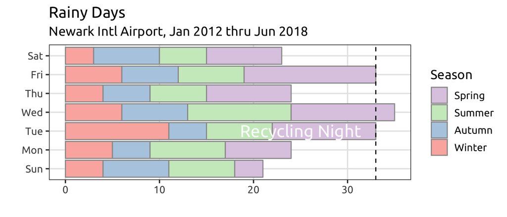

There are certainly more rainy Tuesdays than average, but is this significant?

```r
ct %>%
  filter(Weather == 'Rain') %>%
  group_by(Weekday) %>%
  summarize(Count = sum(Count)) %>%
  .$Count %>%
  chisq.test()
```

```
##
##  Chi-squared test for given probabilities
##
## data:  .
## X-squared = 7.3886, df = 6, p-value = 0.2864
```

Well, there you have it. This is a resounding *“No”*. I can’t reject the null hypothesis, meaning that the evidence doesn’t substantiate a claim otherwise. Our p-value of .29 is much higher than the standard .05 threshold.

Coming to a conclusion, it’s fair to admit we don’t have the bandwidth (or self-awareness) to methodically list and prove out everything our gut has been deciding for us over the years. This was a toy example, but when the stakes are higher I hope this writeup serves as a gentle reminder to **not** trust your instincts. I know I can’t!